# Analyzing Economic Impacts of COVID-19 Through Travel Data

## By Sharvari Bhatt, Lydia Kim, Yi Fan Lim, Saeed Razavi, Leon Smith

```python
#Imports
import pandas as pd
import os
import numpy as np
import matplotlib.pyplot as plt
import seaborn as sns
%matplotlib inline
from sklearn.cross_decomposition import CCA
```

```python
df = pd.read_excel('.\\Econ and CS Project Data.xlsx', sheet_name=0).T
#relative addressing. Keep the ipynb in the same file as the xlsx

header = df.iloc[0]
header.name = 'Feature'
df = df[1:]
df.columns = header

df
```

| Feature | Real PCE for Goods | Real PCE for Services | Real GDP | Personal income | Disposable personal income | Annual Mean Unemployment Rate | Air carrier domestic all services vehicle-miles | Highway vehicle-miles | Transite vehicle-miles | Rail train-miles | Air-travel arrivals in the USA | Air-travel departures from the USA |
| --- | --- | --- | --- | --- | --- | --- | --- | --- | --- | --- | --- | --- |
| Units | [Index numbers, 2012=100] | [Index numbers, 2012=100] | [Billions of chained (2012) dollars] | [Billions of dollars] | [Billions of chained (2012) dollars] | % | Millions of Vehicle Miles | Millions of Vehicle Miles | Millions of Vehicle Miles | Millions of Train Miles | Thousands of Passengers | Thousands of Passengers |
| 1975 | 30.905 | 33.884 | 5644.8 | 1369.4 | 2.5 | 8.475 | 1637.58 | 1.32766e+06 | 2176.2 | 432.557 | 12646 | 12053 |
| 1980 | 35.578 | 40.312 | 6759.2 | 2323.6 | 0.7 | 7.175 | 2276.02 | 1.5273e+06 | 2286.8 | 458.498 | 20262 | 19256 |
| 1985 | 43.508 | 47.953 | 7951.1 | 3524.9 | 3 | 7.19167 | 3025.74 | 1.77483e+06 | 2790.7 | 377.292 | 24155 | 22487 |
| 1990 | 50.039 | 57.345 | 9365.5 | 4913.8 | 2 | 5.61667 | 3963.27 | 2.14436e+06 | 3241.6 | 412.582 | 42712.2 | 42182.8 |
| 1991 | 49.046 | 58.242 | 9355.4 | 5084.9 | 0.7 | 6.85 | 3854.41 | 2.17205e+06 | 3306.3 | 408.974 | 41236 | 40819.5 |
| 1992 | 50.591 | 60.571 | 9684.9 | 5420.9 | 4.2 | 7.49167 | 3995.09 | 2.24715e+06 | 3354.5 | 424.241 | 45084.5 | 44799.6 |
| 1993 | 52.693 | 62.444 | 9951.5 | 5657.9 | 1.7 | 6.90833 | 4156.4 | 2.29638e+06 | 3434.9 | 440.446 | 47353 | 46935.8 |
| 1994 | 55.472 | 64.356 | 10352.4 | 5947.1 | 2.7 | 6.1 | 4377.89 | 2.35759e+06 | 3467.5 | 474.896 | 49558.3 | 49046.4 |
| 1995 | 57.129 | 66.241 | 10630.3 | 6291.4 | 3.3 | 5.59167 | 4627.81 | 2.4227e+06 | 3550 | 490.271 | 52990.8 | 52582.1 |
| 1996 | 59.687 | 68.157 | 11031.4 | 6678.5 | 3.2 | 5.40833 | 4807.14 | 2.48585e+06 | 3081.56 | 498.792 | 56820.4 | 56499.4 |
| 1997 | 62.524 | 70.34 | 11521.9 | 7092.5 | 3.7 | 4.94167 | 4907.13 | 2.5617e+06 | 3200.92 | 506.954 | 60315.3 | 60168.2 |
| 1998 | 66.703 | 73.536 | 12038.3 | 7606.7 | 5.9 | 4.5 | 5029.72 | 2.63152e+06 | 3346.95 | 507.947 | 62855.9 | 62578.2 |
| 1999 | 71.976 | 76.332 | 12610.5 | 8001.9 | 3.3 | 4.21667 | 5326.2 | 2.69134e+06 | 3499.71 | 524.442 | 66754.5 | 66454.4 |
| 2000 | 75.702 | 80.169 | 13131 | 8652.6 | 5 | 3.96667 | 5662.23 | 2.74692e+06 | 3604.54 | 539.001 | 72204.9 | 71546.2 |
| 2001 | 77.995 | 81.959 | 13262.1 | 9005.6 | 2.7 | 4.74167 | 5544.72 | 2.79561e+06 | 3735.4 | 535.546 | 65460.4 | 65154.2 |
| 2002 | 81.029 | 83.472 | 13493.1 | 9159 | 3 | 5.78333 | 5612.65 | 2.85551e+06 | 3854.6 | 537.292 | 62851.2 | 62611.7 |
| 2003 | 84.997 | 85.349 | 13879.1 | 9487.5 | 2.7 | 5.99167 | 6105.74 | 2.89022e+06 | 3914.77 | 553.458 | 62959.9 | 62848.2 |
| 2004 | 89.342 | 87.924 | 14406.4 | 10035.1 | 3.3 | 5.54167 | 6602.06 | 2.96479e+06 | 3971.62 | 571.855 | 70848.6 | 70521.2 |
| 2005 | 93.044 | 90.778 | 14912.5 | 10598.2 | 1.6 | 5.08333 | 6716.47 | 2.98943e+06 | 4054.26 | 583.765 | 75121.3 | 74985.9 |
| 2006 | 96.48 | 93.25 | 15338.3 | 11381.7 | 4 | 4.60833 | 6605.6 | 3.01437e+06 | 4126.84 | 598.69 | 77699 | 77317.8 |
| 2007 | 99.172 | 95.04 | 15626 | 12007.8 | 2.3 | 4.61667 | 6732.53 | 3.03112e+06 | 4237.74 | 580.959 | 80650.3 | 80271.6 |
| 2008 | 96.184 | 96.253 | 15604.7 | 12442.2 | 1 | 5.8 | 6446 | 2.97653e+06 | 4375.21 | 561.959 | 80547.9 | 80426.3 |
| 2009 | 93.184 | 95.943 | 15208.8 | 12059.1 | -0.2 | 9.28333 | 5935.27 | 2.95676e+06 | 4474.55 | 474.535 | 75809.3 | 75726.9 |
| 2010 | 95.821 | 97.127 | 15598.8 | 12551.6 | 2 | 9.60833 | 5975.78 | 2.96727e+06 | 4400.18 | 513.359 | 80286.9 | 79878.8 |
| 2011 | 97.913 | 98.82 | 15840.7 | 13326.8 | 2.3 | 8.93333 | 6004.58 | 2.9504e+06 | 4331.45 | 530.401 | 83341.2 | 83120.6 |
| 2012 | 100 | 100 | 16197 | 14010.1 | 3.3 | 8.075 | 5956.17 | 2.96943e+06 | 4346.57 | 537.788 | 87108.5 | 86660.7 |
| 2013 | 103.147 | 100.63 | 16495.4 | 14181.1 | -1.3 | 7.35833 | 5964.98 | 2.98828e+06 | 4413.34 | 542.394 | 91549.9 | 90815.3 |
| 2014 | 107.351 | 103.065 | 16912 | 14991.7 | 4.1 | 6.15833 | 5947.35 | 3.02566e+06 | 4429.08 | 556.18 | 96224.6 | 95525.3 |
| 2015 | 112.393 | 106.37 | 17403.8 | 15717.8 | 4.1 | 5.275 | 6045.82 | 3.09537e+06 | 4495.31 | 532.388 | 102431 | 101560 |
| 2016 | 116.464 | 108.848 | 17688.9 | 16121.2 | 1.8 | 4.875 | 6227.35 | 3.17441e+06 | 4545.01 | 490.654 | 108137 | 107293 |
| 2017 | 121.048 | 111.034 | 18108.1 | 16878.8 | 2.9 | 4.34167 | 6337.82 | 3.21235e+06 | 4574.24 | 503.111 | 113819 | 113157 |
| 2018 | 125.993 | 113.829 | 18638.2 | 17819.2 | 4 | 3.89167 | 6609.01 | 3.24033e+06 | 4591.94 | 514.347 | 119791 | 99483.9 |

```python
econ_keys = ['Real PCE for Goods', 'Real PCE for Services', 'Real GDP','Personal income', 'Disposable personal income','Annual Mean Unemployment Rate']
travel_keys = ['Air carrier domestic all services vehicle-miles','Highway vehicle-miles', 'Transite vehicle-miles', 'Rail train-miles','Air-travel arrivals in the USA', 'Air-travel departures from the USA']
```

Both the truncated correlation matrix and the pair plot below show comparisons of our datasets with economic data on the vertical axis and travel data on the horizontal. The correlation matrix shows the correlation between any two features at the position where their row and column intersect. An intution for that correlation can be gleamed by looking at the same on the pair plot. This knowledge of individual correlations can help us later when explaining the results of our canonical correlation analysis.

```python
df.drop(['Units']).astype(float).corr().head(6)[travel_keys]
#Correlation matrix shows correlation of each feature row by column
```

| Feature | Air carrier domestic all services vehicle-miles | Highway vehicle-miles | Transite vehicle-miles | Rail train-miles | Air-travel arrivals in the USA | Air-travel departures from the USA |
| --- | --- | --- | --- | --- | --- | --- |
| Real PCE for Goods | 0.898137 | 0.935567 | 0.948564 | 0.682776 | 0.973161 | 0.968711 |
| Real PCE for Services | 0.927224 | 0.967045 | 0.971635 | 0.692544 | 0.976104 | 0.979044 |
| Real GDP | 0.927311 | 0.964789 | 0.964390 | 0.704482 | 0.978296 | 0.980182 |
| Personal income | 0.855910 | 0.913809 | 0.948694 | 0.612700 | 0.982283 | 0.975725 |
| Disposable personal income | 0.078395 | 0.091216 | -0.076769 | 0.155578 | 0.091412 | 0.072013 |
| Annual Mean Unemployment Rate | -0.340533 | -0.314819 | -0.097174 | -0.367904 | -0.309863 | -0.287489 |

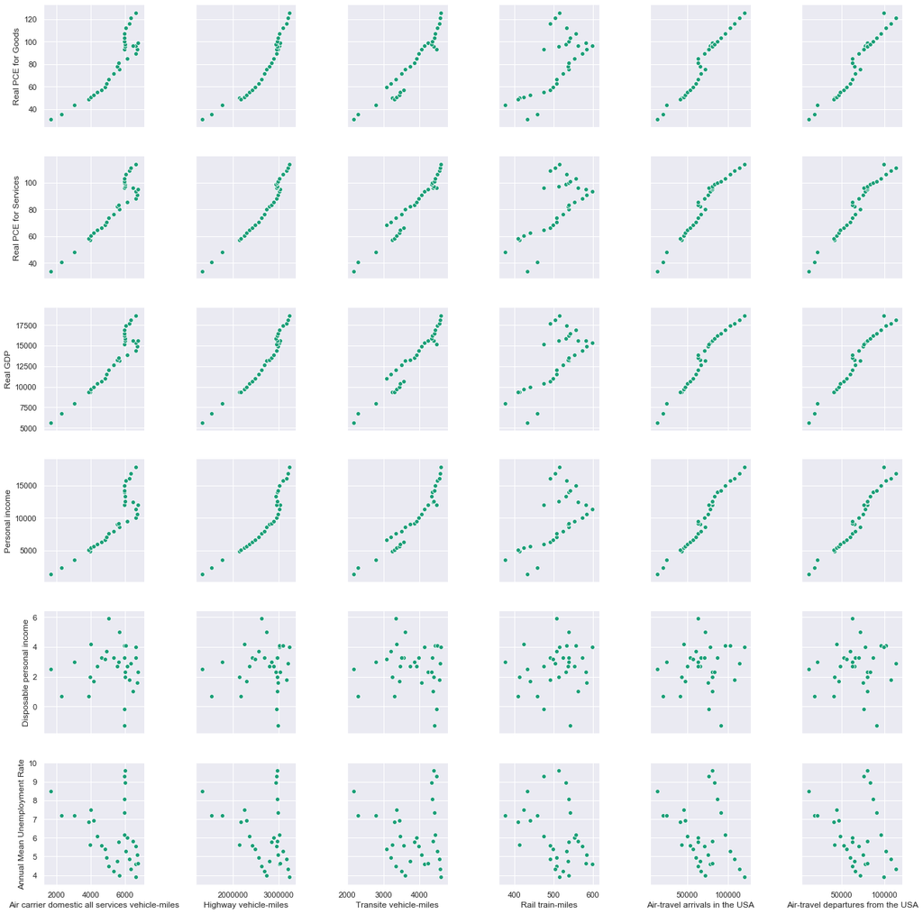

```python
sns.set(style="darkgrid")
sns.set_palette("Dark2")

sns.pairplot(df.drop(['Units']),height=3, x_vars = travel_keys, y_vars = econ_keys)
plt.show()
```

```python
#Define input and output datasets
econ = df.drop(['Units']).astype(float)[econ_keys]
travel = df.drop(['Units']).astype(float)[travel_keys]
```

```python
cca = CCA(n_components=5)
cca.fit(travel, econ)

U = pd.DataFrame(cca.x_rotations_)
U.rename(index={0:"Air v-mi",1:"Highway v-mi",2:"Transit v-mi",3:"Rail t-mi",4:"Air Arrivals",5:"Air Departures"}, inplace=True)
print("Travel Canonical Components:")
print(U)

V = pd.DataFrame(cca.y_rotations_)
V.rename(index={0:"RPCE Goods",1:"RPCE Services",2:"RGDP",3:"Income",4:"Disp. Income",5:"Unemployment"}, inplace=True)
print("\nEconomic Canonical Components:")
print(V)

print('\n')
travel_c, econ_c = cca.fit_transform(travel, econ)

print("First Canonical Correlation =", np.corrcoef(travel_c[:,0], econ_c[:,0])[0,1])
print("Second Canonical Correlation =", np.corrcoef(travel_c[:,1], econ_c[:,1])[0,1])
print("Third Canonical Correlation =", np.corrcoef(travel_c[:,2], econ_c[:,2])[0,1])
print("Fourth Canonical Correlation =", np.corrcoef(travel_c[:,3], econ_c[:,3])[0,1])
print("Fifth Canonical Correlation =", np.corrcoef(travel_c[:,2], econ_c[:,4])[0,1])
```

```
Travel Canonical Components:
                       0         1         2         3         4
Air v-mi        0.038582 -0.271694  0.608069  0.541007 -0.800066
Highway v-mi    0.934561 -0.574290 -0.640421 -1.354686  0.627722
Transit v-mi    0.155858  0.198246 -0.552959  0.524638 -0.024256
Rail t-mi       0.065101  0.006902  0.049004  0.225767  0.204007
Air Arrivals    0.292080  0.793420  0.549590  0.011254 -0.827718
Air Departures  0.106143 -0.126657  0.014686  0.147739  0.842217

Economic Canonical Components:
                      0         1         2         3         4
RPCE Goods    -0.237604 -0.122690  0.002225  1.737066 -2.158120
RPCE Services  0.932752 -0.348136 -1.109130 -7.834337 -4.880769
RGDP           0.056376 -0.482085  1.101273  7.697494  6.532923
Income        -0.260555  0.982182 -0.001795 -1.466189  0.531744
Disp. Income   0.002287 -0.003257  0.009979 -0.133741  0.043234
Unemployment  -0.049461 -0.019655 -0.025593  0.425948  0.173075


First Canonical Correlation = 0.9989758578482323
Second Canonical Correlation = 0.9782451876298951
Third Canonical Correlation = 0.8213386352200954
Fourth Canonical Correlation = 0.6902648497373676
Fifth Canonical Correlation = -1.3589100461251289e-15
```

The goal of this canonical correlation analysis (CCA) was to determine how our economic measures and our travel data relate by projecting them as input and output data onto single dimensions with maximal correlation. The particular data components were chosen to gain insight a wide array of macroeconomic health indicators and different types of travel. While CCA is often used for dimensionality reduction as a means of enhancing the training of machine learning models, valuable insights can also be gained by examining the canonical correlations and their components. The first three travel canonical components are very strongly correlated with their respective economic canonical components, so we can say with relative confidence that the travel data is indeed correlated with the economic data. Then, looking at the makeup of individual canonical components in each canonical correlation, we can gain insights into relationships between input and output features in context. For example, in the first canonical correlation, the travel canonical component has a high weight on Highway v-mi compared to the weights representing the other travel features. Likewise, the first canoncial correlation's economic canonical components are dominated by the weight of RPCE Services. Given these facts together, they could imply a strong relationship betwen these features, given their surrounding context. Indeed, if we look back at our pairplot, we see that those two features do correlate very strongly.

Citation: This canonical correlation analysis is based on code by Professor Tom Fletcher, distributed to his Foundations of Data Analysis class at UVA. The aforementioned code can be found here: https://tomfletcher.github.io/FoDA/examples/CCA.ipynb

Follow this link for phase 2 of this project: https://observablehq.com/@limyifan1/international-flight-map